# Homework R #9 (Токенизация и лемматизация)

Latypov Gleb

2023-12-06

# Компьютерный анализ текста

#### *«Финансист» — роман американского писателя Теодора Драйзера, опубликованный в 1912 году, первый из цикла «Трилогия желания».*

[figure not shown]

[Читать оригинал романа](https://www.gutenberg.org/ebooks/1840)

# Токенизация

> В рамках компьютерного анализа текста мною был выбран роман Теодора Драйзера “Финансист”. С оригиналом произведения вы можете ознакомиться на сайте [gutenberg](https://www.gutenberg.org/). Текст был спарсен с данного сайта в формате .txt. Он был токенезирован и занесен в таблицу “token_theodore” c колонками “chapter” и “word”. Ознакомиться с результатами преобразованной таблицей, а также с кодом вы можете ниже.

```r
#используемые библиотеки
library(tidytext)
library(tokenizers)
library(dplyr)
library(stringr)
library(udpipe)
library(ggplot2)
library(rvest)
library(wordcloud2)
```

```r
#Загрузим данные
#подвязываем url с Драйзером и парсим сайт с ссылкой
url <- read_html("https://www.gutenberg.org/ebooks/1840")
#находим ссылку "Plain Text UTF-8"
link <- url %>%
  html_nodes("a") %>%
  html_attr("href") %>%
  str_subset("1840.txt") %>%
  paste("https://www.gutenberg.org", ., sep="")
#считываем текст
text <- readLines(link)

#создаем таблицу "theodore" с текстом романа Драйзера и удаляем первые 40  и последние 397 строчек (там содержится мусор)
theodore <- tibble(Text_novel = text)
theodore <- theodore %>%
  slice(41:n()) %>%
  slice(1:(nrow(theodore)-398))

#создадим нетокинезированную таблицу для БУДУЩЕЙ лематизации
theo_for_lemma <- theodore %>%
  mutate(chapter = cumsum(str_detect(Text_novel, "^Chapter [\\DIVXLC]")))

#модифицируем таблицу "theodore" и добавим второй столбец с "chapter"
#(регулярка ищет нам все chapter)
theodore <- theodore %>%
  mutate(Text_novel = str_to_lower(Text_novel),
         chapter = cumsum(str_detect(Text_novel, "^chapter [\\divxlc]")))

#создаем еще таблицу в которой строки уже разбиты на токены по одному слову
token_theodore <- theodore %>%
  unnest_tokens(word, Text_novel)
```

### Первые 10 результатов таблицы

```
## # A tibble: 10 × 2
##    chapter word
##      <int> <chr>
##  1       1 chapter
##  2       1 i
##  3       1 the
##  4       1 philadelphia
##  5       1 into
##  6       1 which
##  7       1 frank
##  8       1 algernon
##  9       1 cowperwood
## 10       1 was
```

### Получение результатов

> Далее поставленной целью было найти словесные 2-грамм, которые встречаются чаще всего на протяжении всего романа. Для хорошей визуализации было решено отобрать топ-10 и построить диаграму.

```r
#найдем словесные 2-грамм встречающиеся чаще всего на протяжении всего романа
grams2_theodore <- theodore %>%
  unnest_tokens(ngrams, Text_novel, token = 'ngrams', n = 2) %>%
  filter(!is.na(ngrams)) %>%
  count(ngrams) %>%
  arrange(-n)

top_n <- grams2_theodore %>%
  top_n(10, n)
```

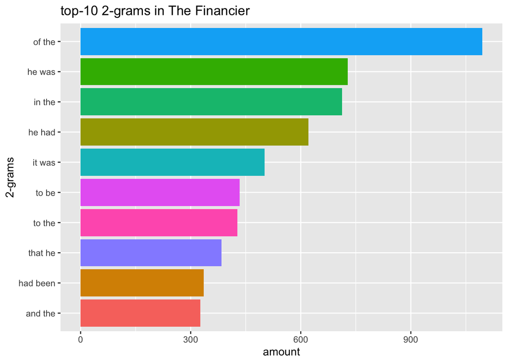

```r
#строим диаграмму
ggplot(data = top_n, aes(x = reorder(ngrams, n), y = n, fill = ngrams)) +
  geom_bar(stat = "identity") +
  coord_flip()+
  labs(x = '2-grams', y = 'amount') +
  ggtitle("top-10 2-grams in The Financier")
```

*Самым частотным оказывается “of the”, который встречается 1095 раз*

# Лематизация

> Для усвоения материала лекции мы осуществим процесс лематизации над первой главой рома Драйзера.

```r
#Лематизация 1 главы
#Используем ранее созданную нетокенизированную таблицу 'theo_for_lemma'
lema_theodore <- theo_for_lemma %>%
  filter(chapter == 1)
#скачаем модель "eng-gum"
#udpipe_download_model(language = "english-gum")
eng_gum <- udpipe_load_model(file = "english-gum-ud-2.5-191206.udpipe")
financier_ann <- udpipe_annotate(eng_gum, x = lema_theodore$Text_novel)

tbl_financier_lema <- as_tibble(financier_ann)
```

### Получение результатов

В качестве модели была взята **“english-gum”** т.к. она обучена на подходящих данных.

Данная таблица полностью интерактивная :)

```r
#первые 10 строчек таблицы
DT::datatable(
  tbl_financier_lema, class = 'cell-border stripe'
  )
```

|  | doc_id | paragraph_id | sentence_id | sentence | token_id | token | lemma | upos | xpos | feats | head_token_id | dep_rel | deps | misc |
| --- | --- | --- | --- | --- | --- | --- | --- | --- | --- | --- | --- | --- | --- | --- |
| 1 | doc1 | 1 | 1 | Chapter I | 1 | Chapter | chapter | NOUN | NN | Number=Sing | 0 | root |  |  |
| 2 | doc1 | 1 | 1 | Chapter I | 2 | I | I | NUM | CD | NumType=Card | 1 | nummod |  | SpacesAfter=\n |
| 3 | doc3 | 1 | 1 | The Philadelphia into which Frank Algernon Cowperwood was born was | 1 | The | the | DET | DT | Definite=Def\|PronType=Art | 2 | det |  |  |
| 4 | doc3 | 1 | 1 | The Philadelphia into which Frank Algernon Cowperwood was born was | 2 | Philadelphia | Philadelphia | PROPN | NNP | Number=Sing | 10 | nsubj |  |  |
| 5 | doc3 | 1 | 1 | The Philadelphia into which Frank Algernon Cowperwood was born was | 3 | into | into | ADP | IN |  | 4 | case |  |  |
| 6 | doc3 | 1 | 1 | The Philadelphia into which Frank Algernon Cowperwood was born was | 4 | which | which | PRON | WDT | PronType=Rel | 9 | obl |  |  |
| 7 | doc3 | 1 | 1 | The Philadelphia into which Frank Algernon Cowperwood was born was | 5 | Frank | Frank | PROPN | NNP | Number=Sing | 9 | nsubj:pass |  |  |
| 8 | doc3 | 1 | 1 | The Philadelphia into which Frank Algernon Cowperwood was born was | 6 | Algernon | Algernon | PROPN | NNP | Number=Sing | 5 | flat |  |  |
| 9 | doc3 | 1 | 1 | The Philadelphia into which Frank Algernon Cowperwood was born was | 7 | Cowperwood | Cowperwood | PROPN | NNP | Number=Sing | 5 | flat |  |  |
| 10 | doc3 | 1 | 1 | The Philadelphia into which Frank Algernon Cowperwood was born was | 8 | was | be | AUX | VBD | Mood=Ind\|Number=Sing\|Person=3\|Tense=Past\|VerbForm=Fin | 9 | aux:pass |  |  |

[output cut: 2368 more lines]

> Предлагаю получить интересные данные из таблицы. Найдем топ-10 самых часто встречающиеся имен собственных (PROPN) из лематизированной таблицы (предположительно это ‘Frank’, ‘Cowperwood’, ‘Butler’).

```r
#Используем ранее созданную  нетокинезированную таблицу 'theo_for_lemma'
#и подгоним все главы под лематизацию
all_lema_theodore <- theo_for_lemma
eng_gum <- udpipe_load_model(file = "english-gum-ud-2.5-191206.udpipe")
all_chapters_financier_ann_ <- udpipe_annotate(eng_gum, x = all_lema_theodore$Text_novel)

#преобразуем все в тиббл
tbl_all_chapters_lemma <- as_tibble(all_chapters_financier_ann_)

#отберем леммы с PROPN
PROPN <- tbl_all_chapters_lemma %>%
  filter(upos == 'PROPN') %>%
  count(lemma) %>%
  arrange(-n) %>%
  top_n(13) %>%
#удалилим ненужные артефакты
  filter(lemma != 'Mr' & lemma != 'Mr.' & lemma !=  'Street')
```

```
## # A tibble: 10 × 2
##    lemma            n
##    <chr>        <int>
##  1 Cowperwood    1098
##  2 Butler         451
##  3 Stener         430
##  4 Aileen         358
##  5 Frank          268
##  6 Mollenhauer    191
##  7 Steger         149
##  8 Philadelphia   120
##  9 Simpson        102
## 10 George          90
```

> Отлично, мы получили таблицу, из которой можно сделать вывод, что наше предположение оказалось почти верным. Самым частотным является фамилия главного героя ‘Cowperwood’, за ним идет ‘Butler’ - фамилия жены Фрэнка - Эйлин(и фамилия ее отца). Stener оказывается на третьем месте - фигура, которая играет важную роль в финансовых махинациях Фрэнка.

> Для красоты и визуального представления отобразим данные на облаке слов.

```r
#построим облако слов
m_colors = c('#730071',"#052F5F", '#FFE900',"#114B5F", "#F34213",'#4A4A48','#5386E4', '#6B2737','#3E2F5B')
b_background = c('#DDFFF7')
wordcloud2(PROPN,
           color = rep_len(m_colors, nrow(PROPN)),
           backgroundColor = b_background,
           size = 0.6)
```

[interactive chart not shown]

# Частеречная разметка

> Напоследок давайте выполним частеречную разметку и посмотрим на результаты использования частей речи в романе.

```r
#обратимся к "tbl_all_chapters_lemma" со всеми главами и леммами, а также уберем от туда пунктуацию
markup <- tbl_all_chapters_lemma %>%
  group_by(upos) %>%
  count() %>%
  filter(upos != "PUNCT") %>%
  arrange(-n)
```

```
## # A tibble: 16 × 2
## # Groups:   upos [16]
##    upos      n
##    <chr> <int>
##  1 NOUN  32543
##  2 PRON  27378
##  3 VERB  26574
##  4 ADP   21804
##  5 DET   16070
##  6 AUX   15619
##  7 ADV   12589
##  8 ADJ   12139
##  9 CCONJ  8300
## 10 PROPN  7771
## 11 PART   7401
## 12 SCONJ  5578
## 13 NUM    2380
## 14 INTJ    565
## 15 X        55
## 16 SYM      15
```

> Итого, глаголы занимают 3 место по частотности, а вот существительные употребляются 32,543 раз. В то время как количество междометий относительно существительных ничтожно мало(всего 565).

> Сделаем диаграмму по полученным данным

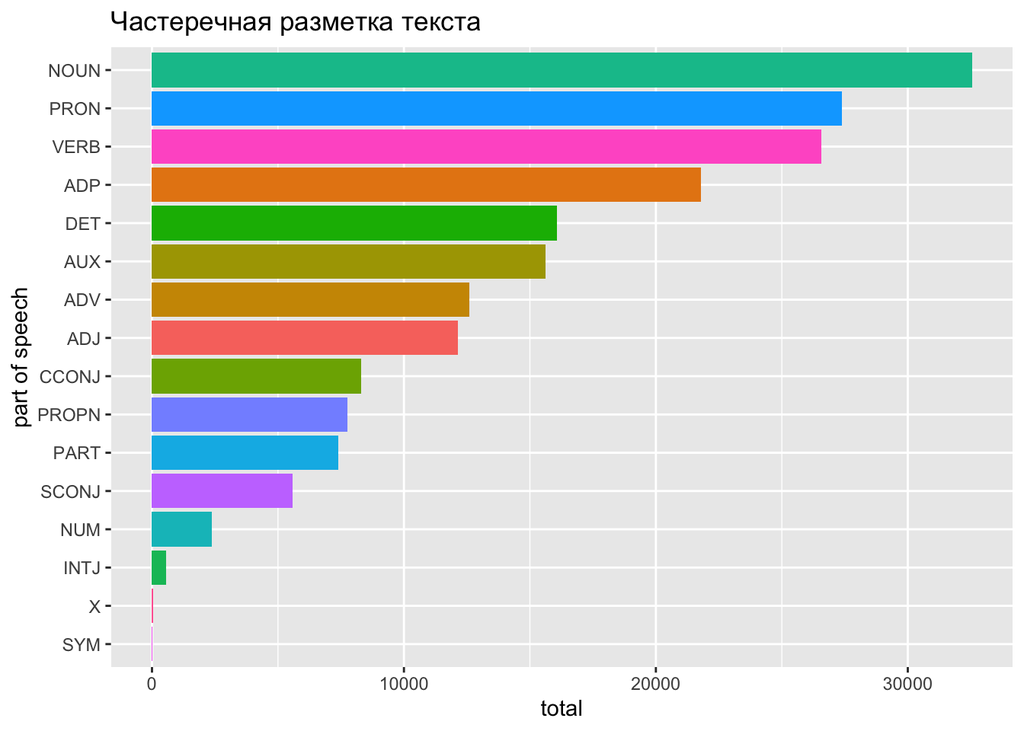

```r
ggplot(data = markup, aes(x = reorder(upos, n), y = n, fill = upos)) +
  geom_bar(stat = "identity") +
  coord_flip()+
  guides(fill = FALSE) +
  labs(x = 'part of speech', y = 'total') +
  ggtitle('Частеречная разметка текста')
```

# Заключение

> Таким образом мы подошли к концу данной работы. Надеюсь вы узнали много интересного из сегодняшнего небольшого исследования. Если вы захотите повторить проделанную работу, то можете заглянуть ко мне на [github](https://github.com/ostpanther/text_analytics). Там вы найдете файл.rmd с кодом.

*Любители рецензий и статей о книгах могут посмотреть интересную статью* (Dreiser 2010)

Dreiser, Theodore. 2010. *The Financier: The Critical Edition*. Vol. 7. University of Illinois Press.